# 结果报告

康

## 1 简介

主要包含3方面内容。首先是统计分析，看各种属性、吃肉态度、狩猎态度之间的关系；其次，主题分析，看关于吃肉的谈论中主要包含什么主题，不同吃肉态度的人更倾向于什么主题；最后是情感分析，看不同吃肉态度的受访者是更消极还是更积极。

原始数据处理方面，仅保留回答了吃肉开放问题的受访者数据（599份）。将非日语文本回答改成日语，且将回答文本中一些假名换成汉字。这样可以充分利用数据集中的数据。例如，在分析性别和吃肉态度之间关系的时候，可以进一步删除性别为空以及吃肉态度为空的数据，再做分析；而分析狩猎态度和吃肉态度之间关系的时候，则在原数据基础上进一步删除狩猎态度为空，以及吃肉态度为空的数据。

## 2 统计分析

这部分主要进行数字型变量之间的统计分析，尤其是性别/年龄/教育水平等属性、对吃鹿肉的态度打分（以下简称”鹿肉态度”）、一些其他问题的回答、对狩猎的态度的打分（以下简称”狩猎态度”）几者之间的关系。

### 2.1 鹿肉态度～属性

吃鹿肉态度～性别：朱珠已进行了卡方分析，此处基于每个受访者数据进行组间对比。首先用shapiro test检验要对比的各组内数据是否为正态分布，如果p < 0.05，则不属于正态分布。可见无论是男性组还是女性组，检测结果均显著，也就是说两者都不是正态分布。

```r
by(as.numeric(survey$ven), survey$gender, shapiro.test)
```

```
## survey$gender: 0
##
##  Shapiro-Wilk normality test
##
## data:  dd[x, ]
## W = 0.82216, p-value < 2.2e-16
##
## -------------------------------------------------------------
## survey$gender: 1
##
##  Shapiro-Wilk normality test
##
## data:  dd[x, ]
## W = 0.87112, p-value = 1.739e-15
```

```r
# 男女组均不符合正态分布，因此用非参数方法进行组间对比。
```

因此，用非参数方法Kruskal-Wallis rank sum test进行对比。对比结果表明男女组的鹿肉态度有差异。进一步计算两组的平均数和中位数，表明男性吃鹿肉态度更高。

```r
get_kruskal("ven", "gender")
```

```
##
##  Kruskal-Wallis rank sum test
##
## data:  as.numeric(survey_sub[[x_name]]) by as.character(survey_sub[[g_name]])
## Kruskal-Wallis chi-squared = 8.8806, df = 1, p-value = 0.002882
```

```r
survey %>%
  filter(!is.na(gender)) %>%
  group_by(gender) %>%
  summarise(
    ven_mean = mean(as.numeric(ven), na.rm = T),
    ven_mid = median(as.numeric(ven), na.rm = T),
    .groups = "drop"
  )
```

```
## # A tibble: 2 × 3
##   gender ven_mean ven_mid
##    <dbl>    <dbl>   <dbl>
## 1      0    0.967       1
## 2      1    0.740       1
```

吃鹿肉态度～年龄组：大部分年龄组不符合正态分布，因此用非参数方法。结果表明不同年龄组之间无显著差异。

```r
by(as.numeric(survey$ven), survey$age, shapiro.test)
```

```
## survey$age: 1
##
##  Shapiro-Wilk normality test
##
## data:  dd[x, ]
## W = 0.88097, p-value = 0.0735
##
## -------------------------------------------------------------
## survey$age: 2
##
##  Shapiro-Wilk normality test
##
## data:  dd[x, ]
## W = 0.85622, p-value = 4.009e-06
##
## -------------------------------------------------------------
## survey$age: 3
##
##  Shapiro-Wilk normality test
##
## data:  dd[x, ]
## W = 0.8603, p-value = 1.252e-06
##
## -------------------------------------------------------------
## survey$age: 4
##
##  Shapiro-Wilk normality test
##
## data:  dd[x, ]
## W = 0.82331, p-value = 1.096e-08
##
## -------------------------------------------------------------
## survey$age: 5
##
##  Shapiro-Wilk normality test
##
## data:  dd[x, ]
## W = 0.84312, p-value = 5.254e-11
##
## -------------------------------------------------------------
## survey$age: 6
##
##  Shapiro-Wilk normality test
##
## data:  dd[x, ]
## W = 0.8325, p-value = 4.175e-09
##
## -------------------------------------------------------------
## survey$age: 7
##
##  Shapiro-Wilk normality test
##
## data:  dd[x, ]
## W = 0.82931, p-value = 1.469e-08
##
## -------------------------------------------------------------
## survey$age: 8
##
##  Shapiro-Wilk normality test
##
## data:  dd[x, ]
## W = 0.8911, p-value = 0.001966
```

```r
get_kruskal("ven", "age")
```

```
##
##  Kruskal-Wallis rank sum test
##
## data:  as.numeric(survey_sub[[x_name]]) by as.character(survey_sub[[g_name]])
## Kruskal-Wallis chi-squared = 10.35, df = 7, p-value = 0.1696
```

吃鹿肉态度～教育水平：无显著差异。

```r
lapply(
  as.character(1:4),
  function(x) {
    filter(survey, education == x)$ven %>%
      as.numeric() %>%
      shapiro.test()
  }
)
```

```
## [[1]]
##
##  Shapiro-Wilk normality test
##
## data:  .
## W = 0.86305, p-value = 1.781e-12
##
##
## [[2]]
##
##  Shapiro-Wilk normality test
##
## data:  .
## W = 0.84947, p-value = 9.786e-16
##
##
## [[3]]
##
##  Shapiro-Wilk normality test
##
## data:  .
## W = 0.81967, p-value = 1.238e-06
##
##
## [[4]]
##
##  Shapiro-Wilk normality test
##
## data:  .
## W = 0.88606, p-value = 0.01895
```

```r
get_kruskal("ven", "education")
```

```
##
##  Kruskal-Wallis rank sum test
##
## data:  as.numeric(survey_sub[[x_name]]) by as.character(survey_sub[[g_name]])
## Kruskal-Wallis chi-squared = 4.456, df = 4, p-value = 0.3478
```

### 2.2 狩猎态度～属性

狩猎态度～性别：男女有显著差异。

狩猎态度～年龄组：不同年龄有显著差异。总体而言，年龄大点儿的受访者态度更高。如果需要的话，可以做两两对比分析。

狩猎态度～教育水平：无显著差异。

```r
# 狩猎态度～性别。
by(as.numeric(survey$hunting), survey$gender, shapiro.test)
```

```
## survey$gender: 0
##
##  Shapiro-Wilk normality test
##
## data:  dd[x, ]
## W = 0.86323, p-value = 1.017e-14
##
## -------------------------------------------------------------
## survey$gender: 1
##
##  Shapiro-Wilk normality test
##
## data:  dd[x, ]
## W = 0.90803, p-value = 1.356e-12
```

```r
get_kruskal("hunting", "gender")
```

```
##
##  Kruskal-Wallis rank sum test
##
## data:  as.numeric(survey_sub[[x_name]]) by as.character(survey_sub[[g_name]])
## Kruskal-Wallis chi-squared = 30.607, df = 1, p-value = 3.16e-08
```

```r
# 狩猎态度～年龄组。
by(as.numeric(survey$hunting), survey$age, shapiro.test)
```

```
## survey$age: 1
##
##  Shapiro-Wilk normality test
##
## data:  dd[x, ]
## W = 0.87536, p-value = 0.06172
##
## -------------------------------------------------------------
## survey$age: 2
##
##  Shapiro-Wilk normality test
##
## data:  dd[x, ]
## W = 0.88862, p-value = 4.541e-05
##
## -------------------------------------------------------------
## survey$age: 3
##
##  Shapiro-Wilk normality test
##
## data:  dd[x, ]
## W = 0.89471, p-value = 2.134e-05
##
## -------------------------------------------------------------
## survey$age: 4
##
##  Shapiro-Wilk normality test
##
## data:  dd[x, ]
## W = 0.89132, p-value = 2.981e-06
##
## -------------------------------------------------------------
## survey$age: 5
##
##  Shapiro-Wilk normality test
##
## data:  dd[x, ]
## W = 0.89725, p-value = 2.232e-08
##
## -------------------------------------------------------------
## survey$age: 6
##
##  Shapiro-Wilk normality test
##
## data:  dd[x, ]
## W = 0.88847, p-value = 9.126e-07
##
## -------------------------------------------------------------
## survey$age: 7
##
##  Shapiro-Wilk normality test
##
## data:  dd[x, ]
## W = 0.83577, p-value = 7.412e-08
##
## -------------------------------------------------------------
## survey$age: 8
##
##  Shapiro-Wilk normality test
##
## data:  dd[x, ]
## W = 0.87238, p-value = 0.001318
```

```r
get_kruskal("hunting", "age")
```

```
##
##  Kruskal-Wallis rank sum test
##
## data:  as.numeric(survey_sub[[x_name]]) by as.character(survey_sub[[g_name]])
## Kruskal-Wallis chi-squared = 24.579, df = 7, p-value = 0.0009007
```

```r
# 狩猎态度～教育水平。
lapply(
  as.character(1:4),
  function(x) {
    filter(survey, education == x)$hunting %>%
      as.numeric() %>%
      shapiro.test()
  }
)
```

```
## [[1]]
##
##  Shapiro-Wilk normality test
##
## data:  .
## W = 0.90035, p-value = 4.456e-10
##
##
## [[2]]
##
##  Shapiro-Wilk normality test
##
## data:  .
## W = 0.89296, p-value = 7.909e-13
##
##
## [[3]]
##
##  Shapiro-Wilk normality test
##
## data:  .
## W = 0.88425, p-value = 8.486e-05
##
##
## [[4]]
##
##  Shapiro-Wilk normality test
##
## data:  .
## W = 0.8994, p-value = 0.03407
```

```r
get_kruskal("hunting", "education")
```

```
##
##  Kruskal-Wallis rank sum test
##
## data:  as.numeric(survey_sub[[x_name]]) by as.character(survey_sub[[g_name]])
## Kruskal-Wallis chi-squared = 6.2396, df = 4, p-value = 0.182
```

```r
# 卡方检验。
gender_hunting_chisq <- table(survey$gender, survey$hunting)
gender_hunting_chisq
```

```
##
##      -2  -1   0   1   2
##   0  16  26  60  80  87
##   1  33  42 103  80  43
```

然后做卡方分析，结果显著：

```r
chisq.test(gender_hunting_chisq)
```

```
##
##  Pearson's Chi-squared test
##
## data:  gender_hunting_chisq
## X-squared = 34.21, df = 4, p-value = 6.749e-07
```

### 2.3 鹿肉态度～狩猎态度

Pearson相关性和Spearman相关性分析都表明，两者显著正相关。不过通常计算一种相关系数就够了。

```r
cor.test(as.numeric(survey$ven), as.numeric(survey$hunting), method = "pearson")
```

```
##
##  Pearson's product-moment correlation
##
## data:  as.numeric(survey$ven) and as.numeric(survey$hunting)
## t = 15.997, df = 573, p-value < 2.2e-16
## alternative hypothesis: true correlation is not equal to 0
## 95 percent confidence interval:
##  0.4964250 0.6097047
## sample estimates:
##       cor
## 0.5556382
```

```r
cor.test(as.numeric(survey$ven), as.numeric(survey$hunting), method = "spearman")
```

```
##
##  Spearman's rank correlation rho
##
## data:  as.numeric(survey$ven) and as.numeric(survey$hunting)
## S = 13770005, p-value < 2.2e-16
## alternative hypothesis: true rho is not equal to 0
## sample estimates:
##       rho
## 0.5654066
```

### 2.4 其他

吃肉态度和是否有农地林地的关系（结果：不显著）：

```r
by(as.numeric(survey$ven), survey$q1, shapiro.test)
```

```
## survey$q1: 1
##
##  Shapiro-Wilk normality test
##
## data:  dd[x, ]
## W = 0.81596, p-value = 0.005936
##
## -------------------------------------------------------------
## survey$q1: 2
##
##  Shapiro-Wilk normality test
##
## data:  dd[x, ]
## W = 0.73212, p-value = 0.00175
##
## -------------------------------------------------------------
## survey$q1: 3
##
##  Shapiro-Wilk normality test
##
## data:  dd[x, ]
## W = 0.83498, p-value = 0.03841
##
## -------------------------------------------------------------
## survey$q1: 4
##
##  Shapiro-Wilk normality test
##
## data:  dd[x, ]
## W = 0.85354, p-value < 2.2e-16
```

```r
get_kruskal("ven", "q1")
```

```
##
##  Kruskal-Wallis rank sum test
##
## data:  as.numeric(survey_sub[[x_name]]) by as.character(survey_sub[[g_name]])
## Kruskal-Wallis chi-squared = 3.0463, df = 3, p-value = 0.3845
```

吃肉态度和是否碰到鹿的关系（结果：不显著）：

```r
by(as.numeric(survey$ven), survey$q2, shapiro.test)
```

```
## survey$q2: 0
##
##  Shapiro-Wilk normality test
##
## data:  dd[x, ]
## W = 0.85907, p-value < 2.2e-16
##
## -------------------------------------------------------------
## survey$q2: 1
##
##  Shapiro-Wilk normality test
##
## data:  dd[x, ]
## W = 0.84051, p-value = 5.387e-14
```

```r
get_kruskal("ven", "q2")
```

```
##
##  Kruskal-Wallis rank sum test
##
## data:  as.numeric(survey_sub[[x_name]]) by as.character(survey_sub[[g_name]])
## Kruskal-Wallis chi-squared = 1.4379, df = 1, p-value = 0.2305
```

吃肉态度和对鹿的印象的关系：各个选项分开看，例如第二个印象选项是”神圣”，我们就看选择了这个选项的人和不选择这个选项的人有什么差别。下面是各个选项的检测结果（可能有重复，不好意思），**有点意思**：q7_b（“神聖”）、q7_e（“残酷”）和q7_f（“可愛い”）的p值显著。

```r
lapply(
  paste0("q7_", head(letters, 8)),
  function(x) {
    print(x)
    get_kruskal("ven", x) %>% print()
  }
)
```

```
## [1] "q7_a"
##
##  Kruskal-Wallis rank sum test
##
## data:  as.numeric(survey_sub[[x_name]]) by as.character(survey_sub[[g_name]])
## Kruskal-Wallis chi-squared = 1.1026, df = 1, p-value = 0.2937
##
## [1] "q7_b"
##
##  Kruskal-Wallis rank sum test
##
## data:  as.numeric(survey_sub[[x_name]]) by as.character(survey_sub[[g_name]])
## Kruskal-Wallis chi-squared = 7.0759, df = 1, p-value = 0.007813
##
## [1] "q7_c"
##
##  Kruskal-Wallis rank sum test
##
## data:  as.numeric(survey_sub[[x_name]]) by as.character(survey_sub[[g_name]])
## Kruskal-Wallis chi-squared = 1.6359, df = 1, p-value = 0.2009
##
## [1] "q7_d"
##
##  Kruskal-Wallis rank sum test
##
## data:  as.numeric(survey_sub[[x_name]]) by as.character(survey_sub[[g_name]])
## Kruskal-Wallis chi-squared = 1.0748, df = 1, p-value = 0.2999
##
## [1] "q7_e"
##
##  Kruskal-Wallis rank sum test
##
## data:  as.numeric(survey_sub[[x_name]]) by as.character(survey_sub[[g_name]])
## Kruskal-Wallis chi-squared = 4.8859, df = 1, p-value = 0.02708
##
## [1] "q7_f"
##
##  Kruskal-Wallis rank sum test
##
## data:  as.numeric(survey_sub[[x_name]]) by as.character(survey_sub[[g_name]])
## Kruskal-Wallis chi-squared = 4.6054, df = 1, p-value = 0.03187
##
## [1] "q7_g"
##
##  Kruskal-Wallis rank sum test
##
## data:  as.numeric(survey_sub[[x_name]]) by as.character(survey_sub[[g_name]])
## Kruskal-Wallis chi-squared = 0.60586, df = 1, p-value = 0.4364
##
## [1] "q7_h"
##
##  Kruskal-Wallis rank sum test
##
## data:  as.numeric(survey_sub[[x_name]]) by as.character(survey_sub[[g_name]])
## Kruskal-Wallis chi-squared = 0.20254, df = 1, p-value = 0.6527
```

```
## [[1]]
##
##  Kruskal-Wallis rank sum test
##
## data:  as.numeric(survey_sub[[x_name]]) by as.character(survey_sub[[g_name]])
## Kruskal-Wallis chi-squared = 1.1026, df = 1, p-value = 0.2937
##
##
## [[2]]
##
##  Kruskal-Wallis rank sum test
##
## data:  as.numeric(survey_sub[[x_name]]) by as.character(survey_sub[[g_name]])
## Kruskal-Wallis chi-squared = 7.0759, df = 1, p-value = 0.007813
##
##
## [[3]]
##
##  Kruskal-Wallis rank sum test
##
## data:  as.numeric(survey_sub[[x_name]]) by as.character(survey_sub[[g_name]])
## Kruskal-Wallis chi-squared = 1.6359, df = 1, p-value = 0.2009
##
##
## [[4]]
##
##  Kruskal-Wallis rank sum test
##
## data:  as.numeric(survey_sub[[x_name]]) by as.character(survey_sub[[g_name]])
## Kruskal-Wallis chi-squared = 1.0748, df = 1, p-value = 0.2999
##
##
## [[5]]
##
##  Kruskal-Wallis rank sum test
##
## data:  as.numeric(survey_sub[[x_name]]) by as.character(survey_sub[[g_name]])
## Kruskal-Wallis chi-squared = 4.8859, df = 1, p-value = 0.02708
##
##
## [[6]]
##
##  Kruskal-Wallis rank sum test
##
## data:  as.numeric(survey_sub[[x_name]]) by as.character(survey_sub[[g_name]])
## Kruskal-Wallis chi-squared = 4.6054, df = 1, p-value = 0.03187
##
##
## [[7]]
##
##  Kruskal-Wallis rank sum test
##
## data:  as.numeric(survey_sub[[x_name]]) by as.character(survey_sub[[g_name]])
## Kruskal-Wallis chi-squared = 0.60586, df = 1, p-value = 0.4364
##
##
## [[8]]
##
##  Kruskal-Wallis rank sum test
##
## data:  as.numeric(survey_sub[[x_name]]) by as.character(survey_sub[[g_name]])
## Kruskal-Wallis chi-squared = 0.20254, df = 1, p-value = 0.6527
```

进一步查看这些显著的选项，对于每个检测，我都查看了选择与否的人数、选择与否的人打分所占比例、选择与否的人的平均打分和打分中位数。可见选择了”神聖”的人在利用鹿肉的态度上更加消极，选择了”残酷”的人在利用鹿肉的态度上也更加消极，类似地，选择了”可愛い”的人在利用鹿肉的态度上也更加消极，可能心理机制不太一样。

```r
table(survey$q7_b)
```

```
##
## FALSE  TRUE
##   570    29
```

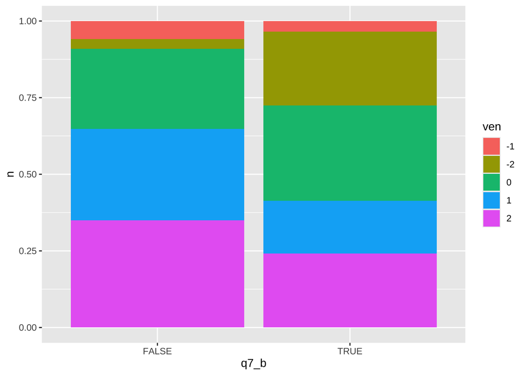

```r
survey %>%
  filter(!is.na(ven)) %>%
  group_by(q7_b, ven) %>%
  summarise(n = n(), .groups = "drop") %>%
  ggplot() +
  geom_col(aes(q7_b, n, fill = ven), position = "fill")
```

```r
by(as.numeric(survey$ven), survey$q7_b, function(x) median(x, na.rm = T))
```

```
## survey$q7_b: FALSE
## [1] 1
## -------------------------------------------------------------
## survey$q7_b: TRUE
## [1] 0
```

```r
by(as.numeric(survey$ven), survey$q7_b, function(x) mean(x, na.rm = T))
```

```
## survey$q7_b: FALSE
## [1] 0.8763251
## -------------------------------------------------------------
## survey$q7_b: TRUE
## [1] 0.137931
```

```r
table(survey$q7_e)
```

```
##
## FALSE  TRUE
##   589    10
```

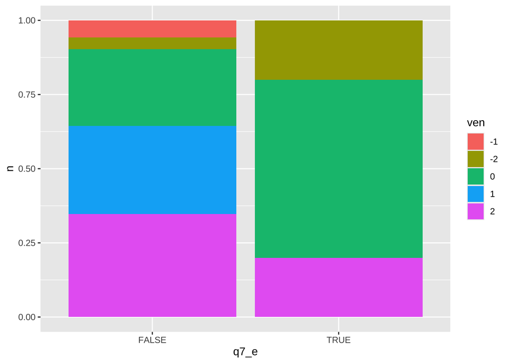

```r
survey %>%
  filter(!is.na(ven)) %>%
  group_by(q7_e, ven) %>%
  summarise(n = n(), .groups = "drop") %>%
  ggplot() +
  geom_col(aes(q7_e, n, fill = ven), position = "fill")
```

```r
by(as.numeric(survey$ven), survey$q7_e, function(x) median(x, na.rm = T))
```

```
## survey$q7_e: FALSE
## [1] 1
## -------------------------------------------------------------
## survey$q7_e: TRUE
## [1] 0
```

```r
by(as.numeric(survey$ven), survey$q7_e, function(x) mean(x, na.rm = T))
```

```
## survey$q7_e: FALSE
## [1] 0.8547009
## -------------------------------------------------------------
## survey$q7_e: TRUE
## [1] 0
```

```r
table(survey$q7_f)
```

```
##
## FALSE  TRUE
##   447   152
```

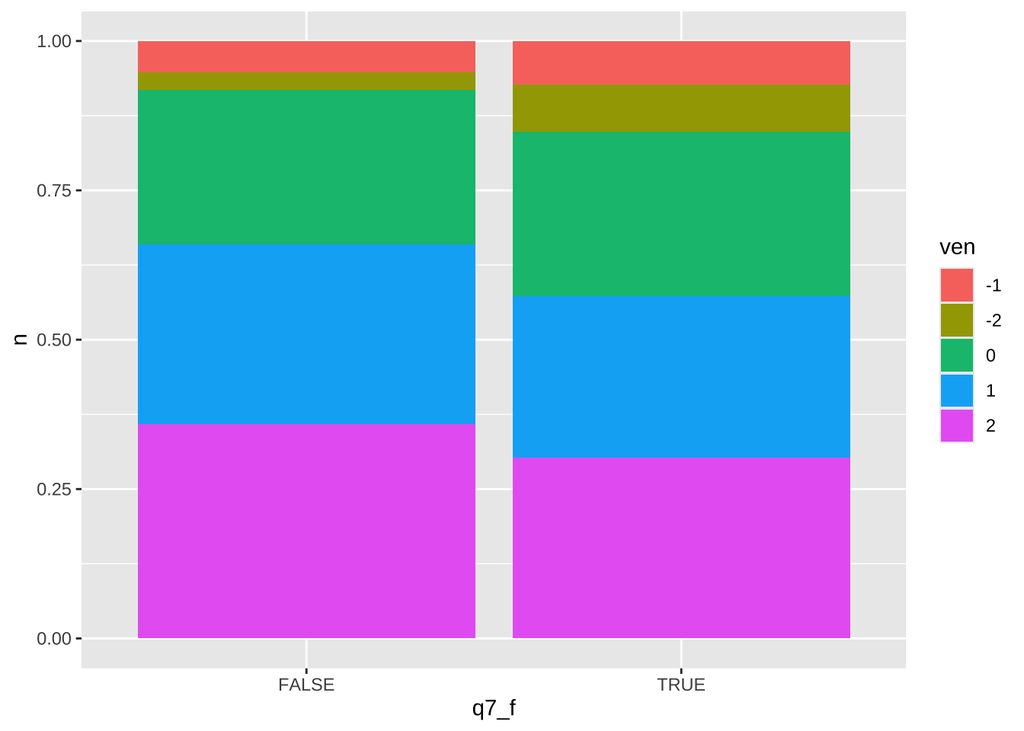

```r
survey %>%
  filter(!is.na(ven)) %>%
  group_by(q7_f, ven) %>%
  summarise(n = n(), .groups = "drop") %>%
  ggplot() +
  geom_col(aes(q7_f, n, fill = ven), position = "fill")
```

```r
by(as.numeric(survey$ven), survey$q7_f, function(x) median(x, na.rm = T))
```

```
## survey$q7_f: FALSE
## [1] 1
## -------------------------------------------------------------
## survey$q7_f: TRUE
## [1] 1
```

```r
by(as.numeric(survey$ven), survey$q7_f, function(x) mean(x, na.rm = T))
```

```
## survey$q7_f: FALSE
## [1] 0.9074492
## -------------------------------------------------------------
## survey$q7_f: TRUE
## [1] 0.6447368
```

## 3 主题分析

具体方法参见之前的报告。在更新后的结果中，文本被分成6个主题。这6个主题的高频关键词是：

```r
library(knitr)
library(kableExtra)
tidy(quan_lda, matrix = "beta") %>%
  group_by(topic) %>%
  slice_max(beta, n = 15) %>%
  mutate(term = reorder_within(term, beta, topic)) %>%
  summarise(term = list(term), .groups = "drop") %>%
  mutate(
    term = unlist(lapply(term, function(x) paste0(x, collapse = ", ")))
  ) %>%
  mutate(term = gsub("_", "", term), term = gsub("[0-9]", "", term)) %>%
  kable() %>%
  kable_styling()
```

| topic | term |
| --- | --- |
| 1 | 食, 鹿, 利用, 肉, 牛, ジビエ, 豚, 害, 鹿肉, 他の, 聞, 狩猟, 鶏, 味, 牛肉 \| |
| 2 | 良い, 命, 方, 無駄, 人, 処分, 殺す, 食料, 殺, 場合, 考え, 一つ, 頂く, , 生命 \| |
| 3 | 活用, 駆除, 鹿, 増え, 有効, 必要, 人間, 食用, 仕方, 良く, 単に, 動物, 食材, 野生, 絶滅 \| |
| 4 | 食肉, 数, 美味, 命, 問題, 悪い, いただく, ことに, バランス, かわいそう, 資源, イメージ, しまう, 食糧, 死 \| |
| 5 | 食べる, 思, できる, 自然, 的, ジビエ, あまり, 食用, 好き, 人間, 文化, よく, 抵抗, 言, 特に \| |
| 6 | 食, べた, いい, 美味しい, ジビエ, おい, 地域, 感じ, なか, 生き, 廃棄, 料理, 考え, しそう, 動物 \| |

各主题的典型文本如下：

```r
quan_id_topic %>%
  group_by(topic) %>%
  arrange(topic, -gamma) %>%
  slice_head(n = 10) %>%
  ungroup() %>%
  # 漏洞：需要提前更改id的类型。
  left_join(mutate(survey, id = as.character(id)), by = "id") %>%
  select(id, topic, ven_reason) %>%
  kable() %>%
  kable_styling()
```

| id | topic | ven_reason |
| --- | --- | --- |
| 108 | 1 | ウシや豚と同様食べられるならありがたくいただくべきだと思うから。（動物の種類で区別するべきでない） \| |
| 68 | 1 | 鹿の肉は他のジビエと違い菌が多いと聞いたから \| |
| 282 | 1 | 理由はありません。鹿の肉も牛や豚、鶏と同じです。 \| |
| 731 | 1 | 狩猟者高齢化による減少の背景の中、ジビエ活用若い狩猟者が増えることを期待します。 \| |
| 335 | 1 | 自然界の回りだから。食べたり、食べられたり。 \| |
| 495 | 1 | 牛、豚、鳥、イノシシなどの動物と同様と思うから \| |
| 711 | 1 | 本当は食利用したくありません。害を与えていると認識するのであれば利用しても良いと思います。慰霊することも忘れてはいけないと思っております。 \| |
| 232 | 1 | 他の動物を食べているのに鹿を食べない理由がない \| |
| 154 | 1 | どうしてもウシや鶏の味に負けてしまいそうなので \| |
| 394 | 1 | 牛も豚も食べているから。イノシシも鶏もです。 \| |
| 677 | 2 | ただむやみに殺生するよりは、最後まで責任を全うするのは良いと思う。以前、ＴＶのニュースで見たが、動物園などの食料通るのも一つの方策だと思う \| |
| 586 | 2 | 今、話題になるジビエはただ捕獲してほかすのではどうかと思う。それもいいけど。犬、猫の餌に加工するとか動物園の肉食獣の餌にすれば良いのでは。こういうことは余り公にならないようにすれば良いのではある団体がうるさいし。 \| |
| 741 | 2 | 生命を奪う代わりに、すべての部位を余すことなく料理し、生命に感謝を捧げる。 \| |
| 491 | 2 | 頭数を減らした方が良いと思っている。せっかくの命生かされるようにした方が良い \| |
| 194 | 2 | 駆除しないですむならそれに越したことはないが、声明をつなげる意味では良いと思う。 \| |
| 607 | 2 | 無意味に殺すよりは頂いた方が良い \| |
| 41 | 2 | 生命は大事です。駆除されて放置されるより人の血や肉になる方が良いと思います。自分勝手な考えだと思いますが… \| |
| 82 | 2 | やむなく駆除が行われた場合、死体をただ処分するよりは利用できた方が良いと思うから。 \| |
| 51 | 2 | 間引く意味を込めて良いと思う \| |
| 144 | 2 | ペット（犬）のエサに入っている \| |
| 611 | 3 | 食材として活用することでプラス方向での問題解決が計れるのではないかと思う。鹿皮の活用も同時に考える。（子供の頃、鹿の皮のカバンや廃ブトンが身近にあった）やわらかくて良かった。 \| |
| 744 | 3 | 駆除のコストを低減させ、駆除を促進することは狼が絶滅した（絶滅させた）人間として必要（健全な生態系維持のため） \| |
| 237 | 3 | 動物も生きる権利あり無益な殺生と思うから。私は他人の意見です。 \| |
| 658 | 3 | 環境の変化により鹿の頭数は増えすぎており積極的な管理が必要。しかし単に殺すのは倫理的ではない。また畜産の環境負荷低減のためにも、野生肉を代替にすることは有効だから。 \| |
| 746 | 3 | 増えすぎているのなら、駆除するのも仕方ないと思うので、有効活用になるのでは。 \| |
| 203 | 3 | 仕方なく駆除されるものもありえるので有効活用をするべきと思います \| |
| 692 | 3 | 単に鹿が増えすぎて、だけで、では駆除しましょうは問題あり \| |
| 269 | 3 | 増えすぎているから適度に活用し、同時に森林の保全も行い共生できればいいのに。 \| |
| 589 | 3 | 増えすぎた鹿は放置したとしても、鹿自身の生活が制限を受け狭まると思うので、ジビエ活用も必要かと思います \| |
| 646 | 3 | この世人間の食べ物はたくさんあります。四足動物自然の中で生きることが大切だと思います \| |
| 729 | 4 | 一定数以上の増加であれば、自然界のバランスのためにも通常の事と考える \| |
| 157 | 4 | 栄養が豊富で良いイメージ。買える場所が少ないからわからない。ネットで取り寄せている。気軽に身近に帰ると嬉しい。 \| |
| 755 | 4 | 何回か頂き、調理、処理によっては、肩ロースなど最高の食材で、近くにジビエのレストランもある。悪い事ではないと思う。 \| |
| 52 | 4 | 食肉が過熱し市街地に出てくる鹿以外も危険にさらされる可能性が高い。市街地であるという事を鹿は理解できない \| |
| 462 | 4 | きちんと処理すれば美味で、栄養豊富。 \| |
| 309 | 4 | 私どもの栄養管理上、食肉は大切です \| |
| 306 | 4 | 身近で比較的入手しやすいのであれば食肉として \| |
| 130 | 4 | 鹿の命を奪ってしまうだけでは申し訳ないのでその命をいただくことで、人間の命を養ってもっらうことに役立てられるから \| |
| 546 | 4 | 適切な生存個数が算定されているのであれば、その範囲での捕獲で対応すれば良いと思う \| |
| 229 | 4 | 命をいただくことは大切なことと考える \| |
| 54 | 5 | できれば野生で暮らしてほしい。人間が自然を破壊することが原因では。人間都合の自然や社会が生態系を壊していて今後が心配です。 \| |
| 756 | 5 | 処理する、しなりに関わらず費用及び手間等が関わる。ならば食を流通の中のテーブルに乗せ食を通して。京都で起きている被害状況を伝えることが（知って頂く）できるのではないかと思っています。 \| |
| 126 | 5 | ジビエは好みがわかれるので手間やコストをかけてまでするメリットがあるのかよくわからない \| |
| 572 | 5 | 食糧難になりつつあると言われています。あまり食べたいとは思わないのですが食べるものが無くなる未来になるなら食べるしかないかな？一般的には売られていない現状が変わるでしょうか？牛や豚、猪などは当たり前に食べているのに…自然で生活しているため病気を持っていないのかなどの衛生、安全性が心配。情報が少ない？クマも食べる人もいますよね？ \| |
| 700 | 5 | 昔から食べるものであると思っている、出町の改進亭で売っていたので \| |
| 441 | 5 | ジビエは好きですが、安全性が保証されているかが気になる \| |
| 29 | 5 | 寄生虫・ダニなどが心配される。病気を持っているかも \| |
| 30 | 5 | 最初から食用と割り切るならＯＫ。増えてしまった鹿を安易に食用として片づけるのはいかがなものか。ジビエがあまり好きではない。 \| |
| 181 | 5 | 食用ではないので、人間の勝手で殺害し食べることに抵抗感がある。 \| |
| 363 | 5 | 精神的に食べる気がしない \| |
| 358 | 6 | 別に食べたくないから（山奥まで旅行してわざわざジビエを食べに行くことはあっても、日常生活で鹿肉を食べたくなる動機がないから。） \| |
| 370 | 6 | 大人になって急に食べてくださいといわれても無理 \| |
| 119 | 6 | 鹿肉はおいしそうだから食べたい。でも殺したくないという葛藤 \| |
| 314 | 6 | 美味しいから。（しっかりと免許制度を徹底してほしい） \| |
| 533 | 6 | 以前食する機会があり食べたらおいしかった \| |
| 597 | 6 | ジビエを活用することは廃棄物を減らし、また地域活性化にもつなげられるから \| |
| 339 | 6 | 体によさそうだから食べたいです。 \| |
| 349 | 6 | 別にあえて食べたくはない \| |
| 113 | 6 | 食べたことがない。食べたくない \| |
| 341 | 6 | 動物がその一生を全うできたように思えるから。 \| |

ChatGPT解读：对于每个主题，将各文本放进GPT，并且询问”请总结下面这些言论的主题，请将回答限制在100字以内：
$$空一行接上排名前10位的典型文本$$
“。例如，如果要知道主题1的含义，就输入以下信息：

```
请总结下面这些言论的主题，请将回答限制在100字以内：

ウシや豚と同様食べられるならありがたくいただくべきだと思うから。（動物の種類で区別するべきでない）
鹿の肉は他のジビエと違い菌が多いと聞いたから
理由はありません。鹿の肉も牛や豚、鶏と同じです。
狩猟者高齢化による減少の背景の中、ジビエ活用若い狩猟者が増えることを期待します。
自然界の回りだから。食べたり、食べられたり。
牛、豚、鳥、イノシシなどの動物と同様と思うから
他の動物を食べているのに鹿を食べない理由がない
本当は食利用したくありません。害を与えていると認識するのであれば利用しても良いと思います。慰霊することも忘れてはいけないと思っております。
どうしてもウシや鶏の味に負けてしまいそうなので
牛も豚も食べているから。イノシシも鶏もです。
```

## 4 情感分析

在这个情感分析中，我们使用LSS（Latent Semantic Scaling）方法：（1）选择一系列积极的种子词汇和消极的种子词汇，这些词汇将构成我们的”积极-消极情绪空间”的坐标；（2）简单来说，衡量其他词汇和这些积极/消极词汇的距离，和积极词汇的距离越近，词语的得分也就越正面；（3）文本的积极或消极就取决于所含词汇在这个情绪空间中的位置。

我选择的积极词汇和消极词汇如下：

```r
seed_word %>%
  kable() %>%
  kable_styling()
```

[output not shown]

在这个情绪空间内，其他词汇的得分和词汇频率如下图。

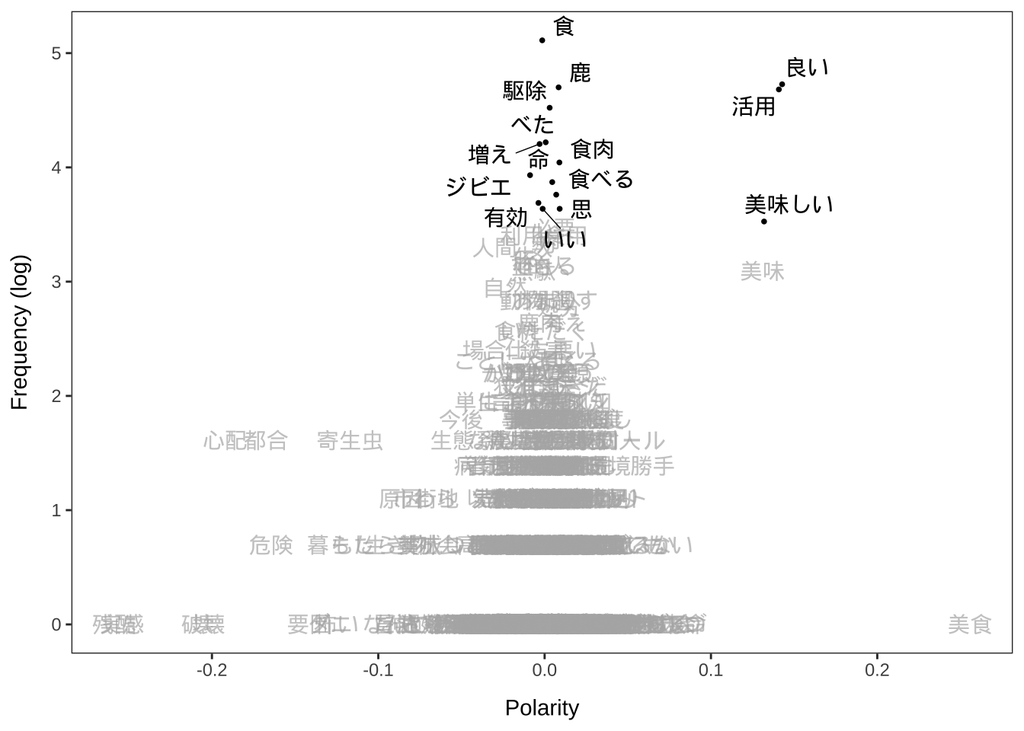

```r
textplot_terms(lss, highlighted = names(topfeatures(quan_dtm, n = 15)))
```

得分最高（积极）的词汇和最低的词汇如下：

```r
head(coef(lss), 20)
```

```
##       美食       良い       活用   美味しい       美味       寿命       つづ
## 0.25578247 0.14279685 0.14083674 0.13194377 0.13094476 0.08399116 0.08399116
##       出会     被ばく     つらい   成り立つ       勝手       多少     いるか
## 0.07785369 0.06801544 0.06801544 0.06755603 0.06492766 0.05873725 0.05824565
## いただける       生体     クリア       条件       付き     あえて
## 0.05416425 0.05396971 0.05388671 0.05388671 0.05388671 0.05325031
```

```r
tail(coef(lss), 20)
```

```
##        賛成        原因      生き物      なんて          神        冒涜
## -0.07432849 -0.08624158 -0.08867860 -0.08953933 -0.08953933 -0.08953933
##        たち    もたらす      寄生虫      暮らし        怖い        ダニ
## -0.08953933 -0.10157827 -0.11695251 -0.12279750 -0.12485639 -0.12882755
##        要因        危険        都合        心配        破壊          壊
## -0.14139350 -0.16443803 -0.16727252 -0.19225331 -0.20517714 -0.20517714
##        実感        残酷
## -0.25405401 -0.25879789
```

可以看出不同吃肉态度的人的情绪得分：

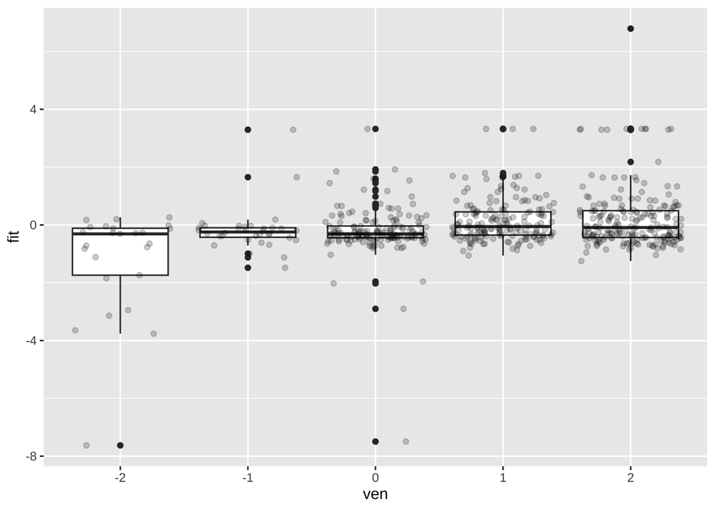

```r
lss_score %>%
  filter(!is.na(ven)) %>%
  ggplot(aes(ven, fit)) +
  geom_boxplot() +
  geom_jitter(alpha = 0.2)
```

```r
lss_score %>%
  filter(!is.na(ven)) %>%
  group_by(ven) %>%
  summarise(
    # lss_mid = median(fit, na.rm = T),
    lss_mean = mean(fit, na.rm = T),
    lss_max = max(fit, na.rm = T),
    lss_min = min(fit, na.rm = T),
    lss_sd = sd(fit, na.rm = T),
    .groups = "drop"
  ) %>%
  kable() %>%
  kable_styling()
```

| ven | lss_mean | lss_max | lss_min | lss_sd |
| --- | --- | --- | --- | --- |
| -2 | -1.1972358 | 0.2619651 | -7.627614 | 1.8118067 |
| -1 | -0.1784253 | 3.2940325 | -1.481703 | 0.7822455 |
| 0 | -0.2107058 | 3.3220276 | -7.494677 | 0.8771652 |
| 1 | 0.1534411 | 3.3220276 | -1.059035 | 0.7482626 |
| 2 | 0.2144537 | 6.7923239 | -1.249019 | 1.0477993 |

按照上次讨论，我挑出了自我打分为-2，但是LSS分析得分却相对积极的人；以及自我打分为2，但是LSS分析得分却相对消极的人。但是结果似乎没有太大参考价值。

```r
lss_score %>%
  filter(ven == "-2") %>%
  arrange(-fit) %>%
  filter(fit > lss_mean_ven0) %>%
  select(id, ven, ven_reason, fit) %>%
  kable() %>%
  kable_styling()
```

[output not shown]

其次是以及自我打分为2，但是LSS分析得分却相对消极的人。不知为何这些的LSS会得负分。

```r
lss_score %>%
  filter(ven == "2") %>%
  arrange(fit) %>%
  filter(fit < lss_mean_ven0) %>%
  select(ven, ven_reason, fit) %>%
  head(10) %>%
  kable() %>%
  kable_styling()
```

[output not shown]